# ON Combined DEG troubleshooting

# 4 Load Object

```r
seu.obj<-readRDS(here("datasets", "3-Oligolineage_final.rds")) #Change to be your object

SO <- seu.obj

rm(seu.obj)

head(SO@meta.data)
```

|  | nCount_RNA | nFeature_RNA | percent_mt | sample_ID | sensitivity | genotype | timepoint | age_group | replicate | age_group_by_timepoint | animal_1 | animal_1_freezer | animal_2 | animal_2_freezer | shortest_freezer_time | longest_freezer_time | day_nuclei_isolated | age_euthanized | age_TAM | cre | floxed_gene | tissue | model | RNA_snn_res.0.3 | seurat_clusters | RNA_snn_res.1.5 | RNA_snn_res.3 | nCount_SCT | nFeature_SCT | … |
| --- | --- | --- | --- | --- | --- | --- | --- | --- | --- | --- | --- | --- | --- | --- | --- | --- | --- | --- | --- | --- | --- | --- | --- | --- | --- | --- | --- | --- | --- | --- |
| y10control_1_yWT10_a_AAAAAAAGGTGTAGCC | 5097.755 | 2351 | 0.01676536 | 1_yWT10_a | 4 | control | 10wks_PT | young | y10control | y10 | KE-C9 | 1_30_24 | GDKE-O5 | 8_5_24 | 13wks | 40wks | day1_11_4_24 | 18wks | 8wks | cre_neg | Myrf | optic_nerve | mouse | 7 | 8 | 8 | 17 | 6548 | 2336 | … |
| y10control_1_yWT10_a_AAAAAAAGTGCAGTGA | 8990.457 | 3387 | 0.00000000 | 1_yWT10_a | 4 | control | 10wks_PT | young | y10control | y10 | KE-C9 | 1_30_24 | GDKE-O5 | 8_5_24 | 13wks | 40wks | day1_11_4_24 | 18wks | 8wks | cre_neg | Myrf | optic_nerve | mouse | 7 | 41 | 8 | 17 | 7634 | 3347 | … |
| y10control_1_yWT10_a_AAAAAAATCTTGAGGG | 4795.234 | 2115 | 0.00000000 | 1_yWT10_a | 4 | control | 10wks_PT | young | y10control | y10 | KE-C9 | 1_30_24 | GDKE-O5 | 8_5_24 | 13wks | 40wks | day1_11_4_24 | 18wks | 8wks | cre_neg | Myrf | optic_nerve | mouse | 2 | 17 | 5 | 3 | 6483 | 2106 | … |
| y10control_1_yWT10_a_AAAAAAATTTCTATCA | 7938.711 | 2954 | 0.01988944 | 1_yWT10_a | 4 | control | 10wks_PT | young | y10control | y10 | KE-C9 | 1_30_24 | GDKE-O5 | 8_5_24 | 13wks | 40wks | day1_11_4_24 | 18wks | 8wks | cre_neg | Myrf | optic_nerve | mouse | 0 | 114 | 2 | 1 | 7500 | 2921 | … |
| y10control_1_yWT10_a_AAAAAACACCCTTATC | 5923.637 | 2623 | 0.00000000 | 1_yWT10_a | 4 | control | 10wks_PT | young | y10control | y10 | KE-C9 | 1_30_24 | GDKE-O5 | 8_5_24 | 13wks | 40wks | day1_11_4_24 | 18wks | 8wks | cre_neg | Myrf | optic_nerve | mouse | 1 | 87 | 3 | 4 | 6653 | 2605 | … |
| y10control_1_yWT10_a_AAAAAACACCTATCCA | 5727.776 | 2447 | 0.00000000 | 1_yWT10_a | 4 | control | 10wks_PT | young | y10control | y10 | KE-C9 | 1_30_24 | GDKE-O5 | 8_5_24 | 13wks | 40wks | day1_11_4_24 | 18wks | 8wks | cre_neg | Myrf | optic_nerve | mouse | 2 | 123 | 6 | 3 | 6640 | 2437 | … |

```r
SO
```

```
## An object of class Seurat
## 58726 features across 49420 samples within 2 assays
## Active assay: SCT (26499 features, 3000 variable features)
##  3 layers present: counts, data, scale.data
##  1 other assay present: RNA
##  3 dimensional reductions calculated: pca, integrated.dr, umap
```

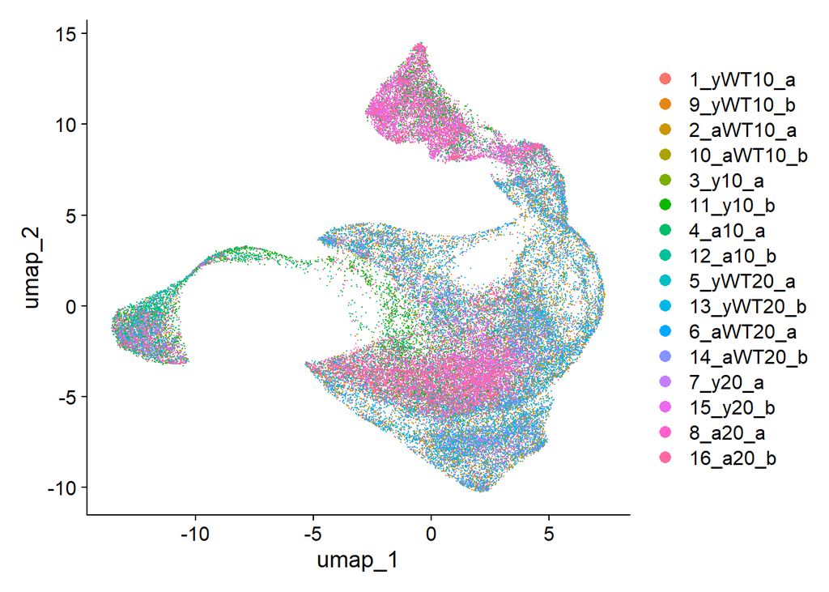

```r
DimPlot(SO)
```

```r
# Downsample because I'm on a computer with only 16GB of RAM (With Seurat v5)
# This code downsamples to 1000 cells for every active identity category (which in this case is Sample ID)

SO <- subset(SO, downsample = 1000)

rm(SO2)
```

# 5 Testing Cluster DEGs

This seems to work fine after PrepSCTFindMArkers()

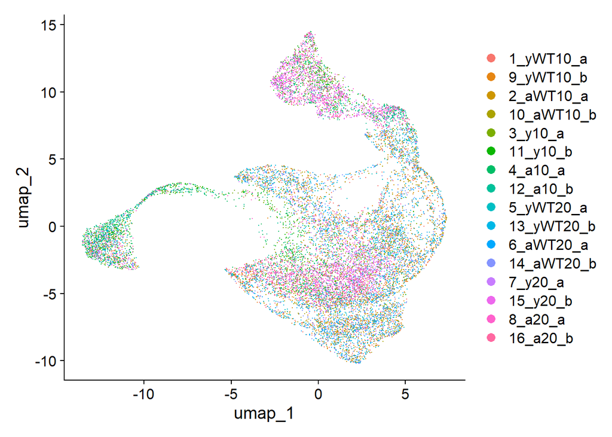

```r
DimPlot(SO)
```

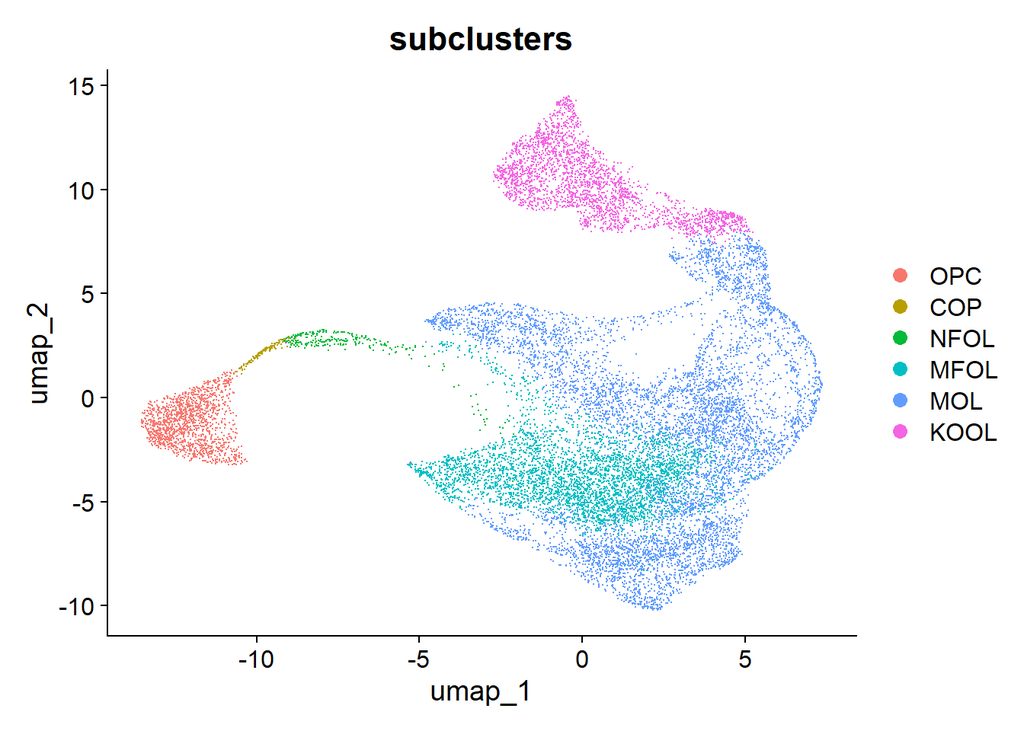

```r
DimPlot(SO, group.by = "subclusters")
```

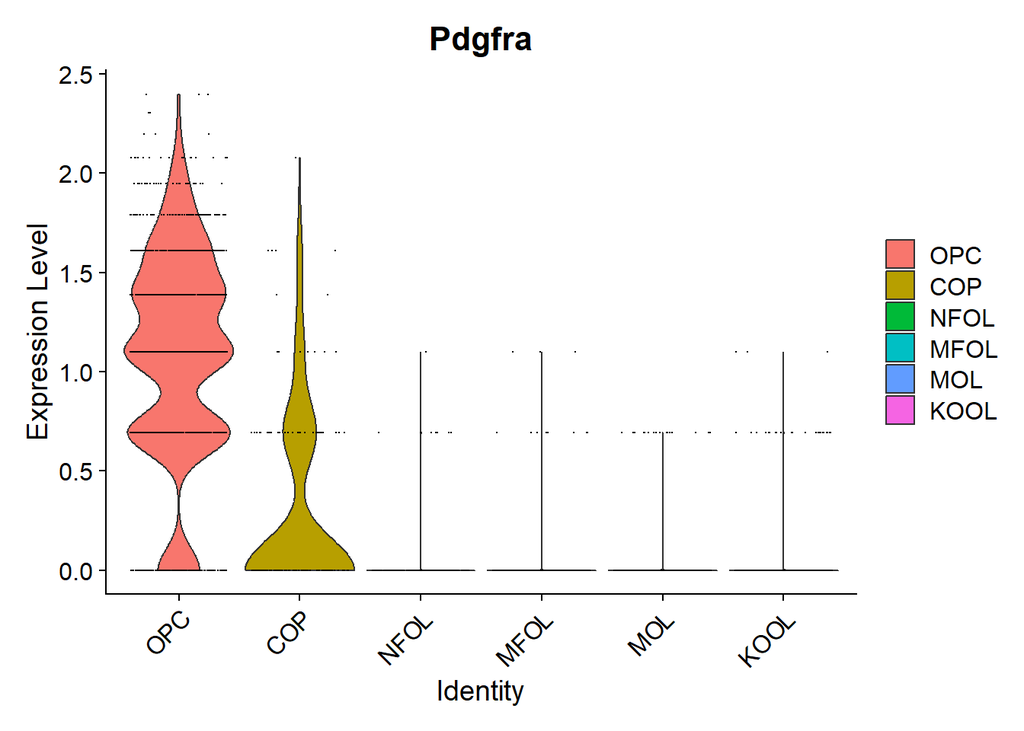

```r
Idents(SO) <- SO@meta.data$subclusters

SO <- PrepSCTFindMarkers(SO)

df <- FindMarkers(SO, ident.1 = "OPC", logfc.threshold = 0.25, min.pct = 0.1)

VlnPlot(SO, "Pdgfra")
```

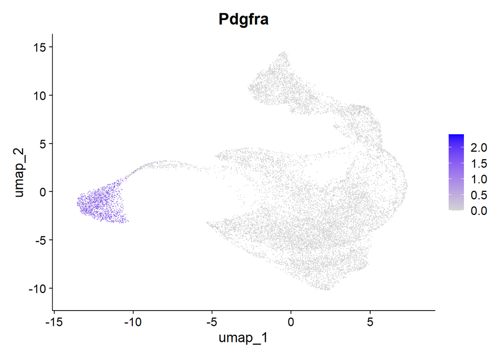

```r
FeaturePlot(SO, "Pdgfra")
```

```r
Idents(SO) <- SO@meta.data$subclusters
```

# 6 Test Treatment DEGs

This doesn’t work! Even though I know I just ran **PrepSCTFindMarkers()**

Error in FindMarkers.SCTAssay(object = data.use, latent.vars = latent.vars, : Object contains multiple models with unequal library sizes. Run `PrepSCTFindMarkers()` before running `FindMarkers()`.

```r
DimPlot(SO)
```

[output not shown]

```r
# df2 <- FindMarkers(SO, ident.1 = "normal", group.by = "myelination", subset.ident = "OPC", logfc.threshold = 0.25, min.pct = 0.1)
```

# 7 Solution

I think this problem stems from multiple issues. Mostly from new Seurat behaviors in V5 vs. V4 that we’re not used to yet.

First, the **RNA assay layers** were never joined together, which I wonder if it messed up the initial SCT calculations. Regardless, there are multiple SCT assays in this object which I think is the heart of the problem.

So my workaround is to:  
1) Set SO default assay to RNA and **join** all the layers  
2) Delete all previous SCT assays  
3) Rerun SCT on the entire object

I was worried that this would lose the UMAP embeddings, but it appears that those are still intact.

```r
DefaultAssay(SO) <- "RNA"

SO <- JoinLayers(SO)

SO[["SCT"]] <- NULL

SO <- SCTransform(SO)
```

```
## Running SCTransform on assay: RNA
```

```
## Running SCTransform on layer: counts
```

```
## vst.flavor='v2' set. Using model with fixed slope and excluding poisson genes.
```

```
## Variance stabilizing transformation of count matrix of size 25651 by 15574
```

```
## Model formula is y ~ log_umi
```

```
## Get Negative Binomial regression parameters per gene
```

```
## Using 2000 genes, 5000 cells
```

```
## There are 129 estimated thetas smaller than 1e-07 - will be set to 1e-07
```

```
## Found 2 outliers - those will be ignored in fitting/regularization step
```

```
## Second step: Get residuals using fitted parameters for 25651 genes
```

```
## Computing corrected count matrix for 25651 genes
```

```
## Wall clock passed: Time difference of 3.388889 mins
```

```
## Determine variable features
```

```
## Centering data matrix
```

```
## Getting residuals for block 1(of 4) for counts dataset
```

```
## Getting residuals for block 2(of 4) for counts dataset
```

```
## Getting residuals for block 3(of 4) for counts dataset
```

```
## Getting residuals for block 4(of 4) for counts dataset
```

```
## Centering data matrix
```

```
## Finished calculating residuals for counts
```

```
## Set default assay to SCT
```

```r
DimPlot(SO)
```

[output not shown]

# 8 Test Treatment DEGs

```r
DimPlot(SO)
```

[output not shown]

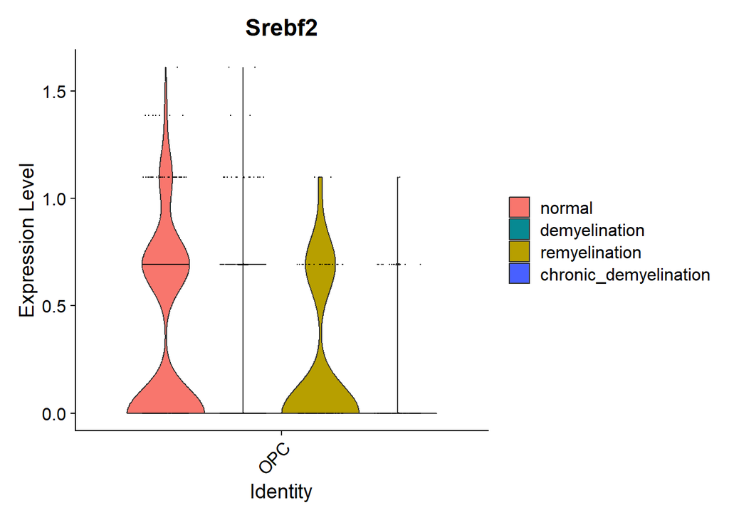

```r
df2 <- FindMarkers(SO, ident.1 = "normal", group.by = "myelination", subset.ident = "OPC", logfc.threshold = 0.25, min.pct = 0.1)

VlnPlot(SO, "Srebf2", idents = "OPC", split.by = "myelination")
```

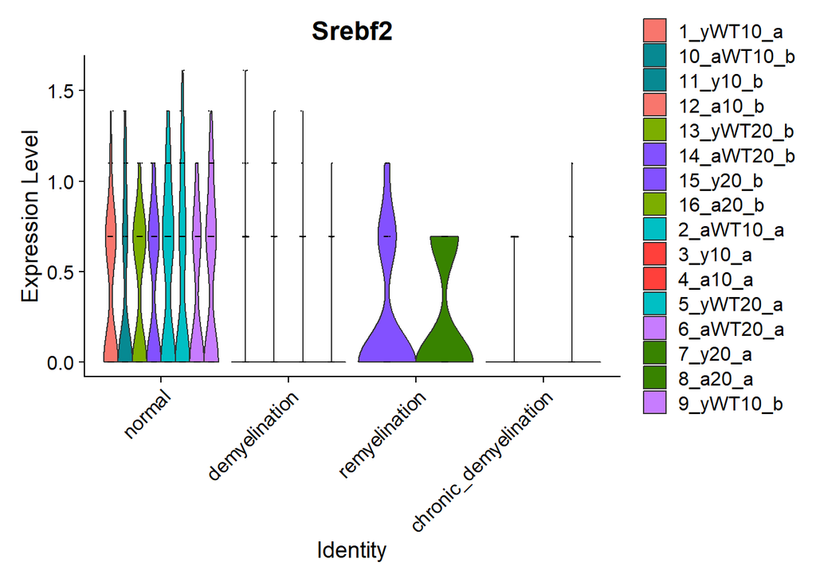

```r
VlnPlot(SO, "Srebf2", idents = "OPC", split.by = "sample_ID", group.by = "myelination")
```

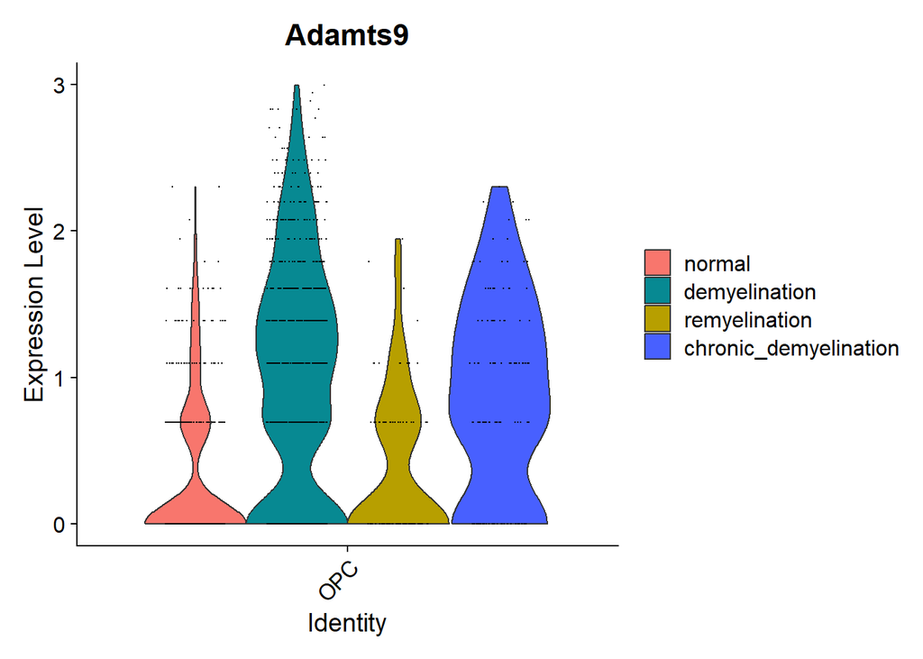

```r
VlnPlot(SO, "Adamts9", idents = "OPC", split.by = "myelination")
```

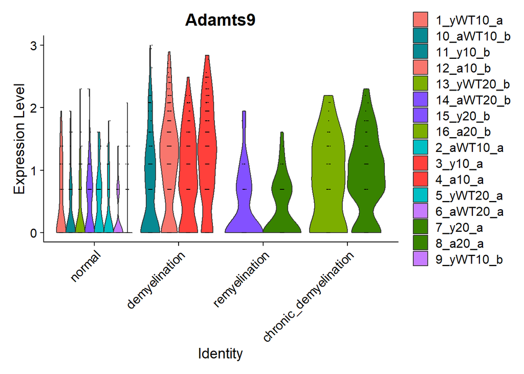

```r
VlnPlot(SO, "Adamts9", idents = "OPC", split.by = "sample_ID", group.by = "myelination")
```